# Survival analysis with Risk Score from gene signatures

June 23, 2020

## Idea

Big data experiments lead to big results. But what to do with a large gene signature from an experiment like [RNASeq](https://de.wikipedia.org/wiki/RNA-Seq)? In 2019, [Hess et al.](https://clincancerres.aacrjournals.org/content/25/5/1505.long) described a convenient way to filter out gene candidates from a large pool and compress it into a **Risk Score**. I applied this idea to a gene signature described by Puram et al..

## What did I do?

- Extract Puram gene signature
- Extract genes for [TCGA](https://www.cancer.gov/about-nci/organization/ccg/research/structural-genomics/tcga) patient cohort
- Use Cox PH models & [*rbsurv*](https://www.bioconductor.org/packages/release/bioc/vignettes/rbsurv/inst/doc/rbsurv.pdf) to identify genes
- Compress gene expression into Risk Score
- Quick survival analysis with [clinical data](https://www.cbioportal.org/study/summary?id=hnsc_tcga_pub) from TCGA

## Results

This is a glimpse on the actual analysis I did with the clinical data from TCGA. Take look.

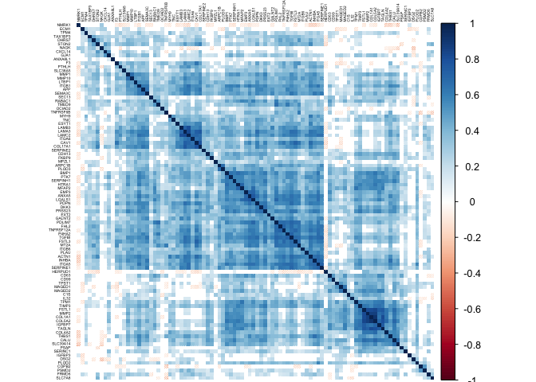

Correlation of all genes described by Puram et al.

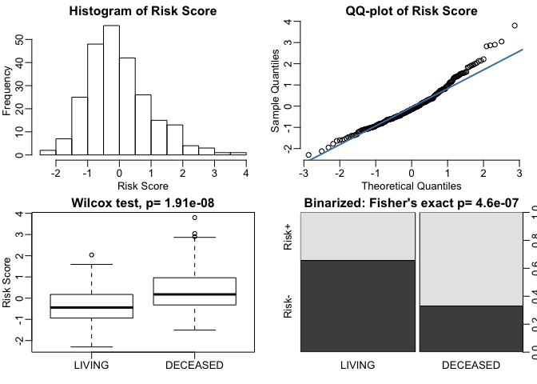

Risk Score in accordance to Hess et al.

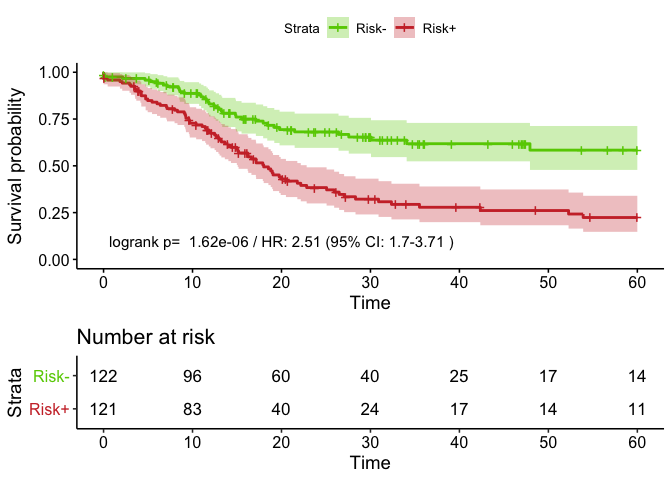

Testing performance of Risk Score in survival analysis

In short, I was able to extract 4 genes from 100 potential candidates and compress them into one simple number: a Risk Score. Then, I used the Risk Score to see if I could group the TCGA patients into low and high Risk (Risk- and Risk+). So, out of 100 genes I could describe 4 genes that do play a role for patient survival and would be candidates for further analysis, e.g. by *in vitro* experiments on functionality. The whole analysis with necessary data sets is uploaded to my [GitHub page](https://github.com/HenrikSchinke/RiskScore_pEMT) and a more detailled description is in my [R section on my website](https://henrikschinke.github.io/RiskScore_pEMT.html).

## What do you need to do it yourself?

- A gene signature you expect to impact clinical outcome
- Patient data, e.g. from TCGA
- Basic to intermediate R knowledge
- Basic understanding of Cox models
- GitHub account to download my data & Scripts